# Reproducible Research

liushuanpeng

Wednesday, January 07, 2015

Loading and preprocessing the data

1.Load the data (i.e. read.csv())

```r
data <- read.csv("D:\\Program Files\\RStudio\\repdata-data-activity\\activity.csv")
```

2.Process/transform the data (if necessary) into a format suitable for your analysis

```r
data$date <- as.Date(data$date, "%Y-%m-%d")
head(data)
```

```
##   steps       date interval
## 1    NA 2012-10-01        0
## 2    NA 2012-10-01        5
## 3    NA 2012-10-01       10
## 4    NA 2012-10-01       15
## 5    NA 2012-10-01       20
## 6    NA 2012-10-01       25
```

What is mean total number of steps taken per day?

```r
splitdata <- split(data,data$date)
splitdata <- as.data.frame(splitdata)
meanstep <- c()
sumstep <- NULL
medianstep <- c()
options(warn=-1)
i <- 1
while(i<ncol(splitdata))
{
  meanstep <- c(meanstep,mean(splitdata[,i], na.rm=TRUE))
  sumstep <- c(sumstep,sum(splitdata[,i]))
  medianstep <- c(medianstep,median(splitdata[,i]))
  i=i+3
}
```

1.Make a histogram of the total number of steps taken each day

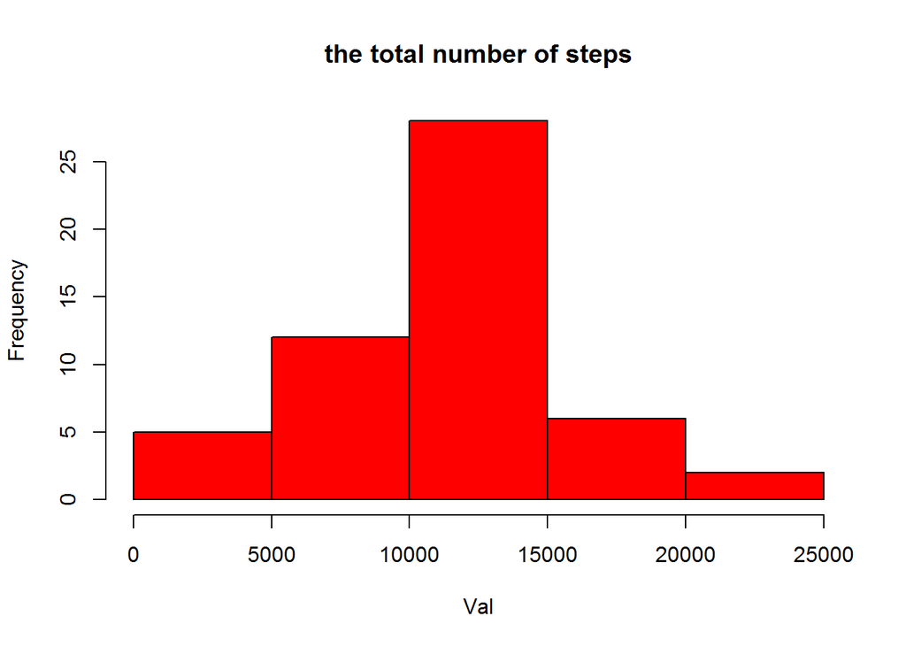

```r
hist(sumstep,col="red",main = "the total number of steps",xlab="Val",ylab="Frequency")
```

2.Calculate and report the mean and median total number of steps taken per day

the mean per day

```r
mean(sumstep,na.rm=TRUE)
```

```
## [1] 10766.19
```

the median per day

```r
median(sumstep,na.rm=TRUE)
```

```
## [1] 10765
```

What is the average daily activity pattern?

```r
inter <- split(data,data$interval)
inter <- as.data.frame(inter)
i <- 1
meaninter <- NULL
while(i < ncol(inter))
{
  meaninter <- c(meaninter,mean(inter[,i],na.rm=TRUE))
  i <- i+3
}
```

1.Make a time series plot (i.e. type = “l”) of the 5-minute interval (x-axis) and the average number of steps taken, averaged across all days (y-axis)

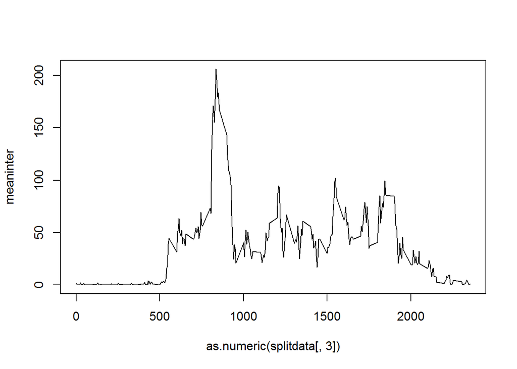

```r
plot(as.numeric(splitdata[,3]), meaninter, type = "l")
```

2.Which 5-minute interval, on average across all the days in the dataset, contains the maximum number of steps?

```r
cbdata <- cbind(splitdata[,3],meaninter)
cbdata[which.max(cbdata[,2]),1]
```

```
##
## 835
```

Imputing missing values

1.Calculate and report the total number of missing values in the dataset (i.e. the total number of rows with NAs)

```r
removena <- na.omit(data)
nrow(data)-nrow(removena)
```

```
## [1] 2304
```

2.Devise a strategy for filling in all of the missing values in the dataset. The strategy does not need to be sophisticated. For example, you could use the mean/median for that day, or the mean for that 5-minute interval, etc. Use the mean for that 5-minute interval to fill.

```r
nasubscript <- which(is.na(data[,1]))
getmod <- nasubscript%%nrow(as.data.frame(meaninter))
n = 1
for(x in getmod)
{

    for(y in 1:nrow(as.data.frame(meaninter)))
    {
      if(x == y)
        {data[nasubscript[n],1] = meaninter[y]}
      if(x == 0)
      {
        data[nasubscript[n],1] = meaninter[288]
      }
    }
    n <- n+1
}
head(data)
```

```
##       steps       date interval
## 1 1.7169811 2012-10-01        0
## 2 0.3396226 2012-10-01        5
## 3 0.1320755 2012-10-01       10
## 4 0.1509434 2012-10-01       15
## 5 0.0754717 2012-10-01       20
## 6 2.0943396 2012-10-01       25
```

```r
newdata <- data
newdata$steps <- NA
```

```r
splitdata <- split(data,data$date)
splitdata <- as.data.frame(splitdata)
meanstep <- c()
sumstep <- NULL
medianstep <- c()
options(warn=-1)
i <- 1
while(i<ncol(splitdata))
{
  meanstep <- c(meanstep,mean(splitdata[,i]))
  sumstep <- c(sumstep,sum(splitdata[,i]))
  medianstep <- c(medianstep,median(splitdata[,i]))
  i=i+3
}
```

Make a histogram

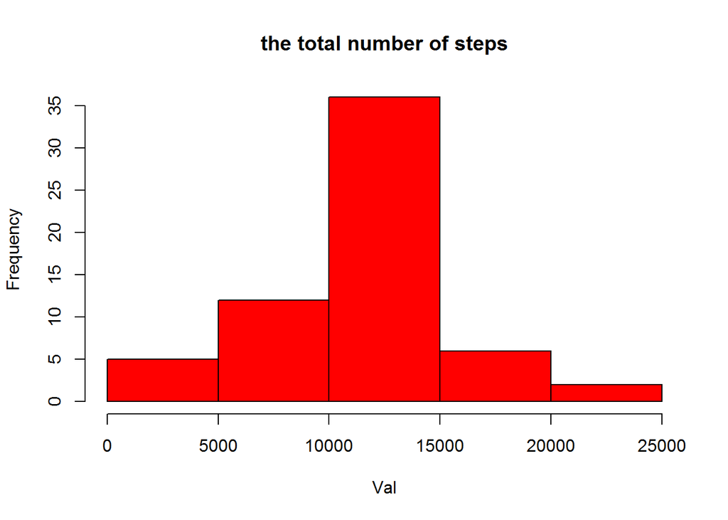

```r
hist(sumstep,col="red",main = "the total number of steps",xlab="Val",ylab="Frequency")
```

the mean

```r
mean(sumstep)
```

```
## [1] 10766.19
```

the median

```r
median(sumstep)
```

```
## [1] 10766.19
```

Are there differences in activity patterns between weekdays and weekends? 1.Create a new factor variable in the dataset with two levels – “weekday” and “weekend” indicating whether a given date is a weekday or weekend day.

```r
week <- weekdays(as.Date(data$date))
workday <- c("星期一","星期二","星期三","星期四","星期五")
c <- c()
for(w in week)
{
  if(w %in% workday)
  {
    c = c(c,"weekdays")
  }
  else
  {
    c = c(c,"weekend")
  }
  #r <- r+1
}
  data[,2] = c
```

2.Make a panel plot containing a time series plot (i.e. type = “l”) of the 5-minute interval (x-axis) and the average number of steps taken, averaged across all weekday days or weekend days (y-axis). See the README file in the GitHub repository to see an example of what this plot should look like using simulated data.

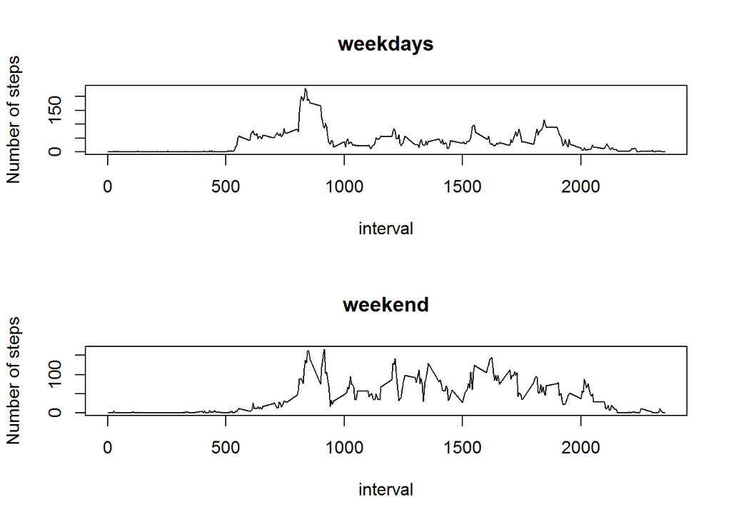

```r
sp <- split(data,data$interval)
sp<-as.data.frame(sp)
n <- 1
meanday <- NULL
meanend <- NULL
while(n < ncol(sp))
{
  meanday <- c(meanday,mean(sp[sp[,n+1]=="weekdays",n],na.rm=TRUE))
  meanend <- c(meanend,mean(sp[sp[,n+1]=="weekend",n],na.rm=TRUE))
  n <- n + 3
}
par(mfrow = c(2, 1))
plot(splitdata[,3],meanday,type="l",main = "weekdays",xlab = "interval",ylab = "Number of steps")
plot(splitdata[,3],meanend,type="l",main = "weekend",xlab = "interval",ylab = "Number of steps")
```